# J.A.I. Lab - Reseach Meeting

**J.A.I. Lab** by Jeongwon Seo

# Applying different kernel functions

```python
# Import packages and set initial plotting options

                            import numpy as np
                            import matplotlib.pyplot as plt
                            import seaborn as sns
                            import GPy
                            GPy.plotting.change_plotting_library('plotly')

                            sns.set_style(
                                style='darkgrid',
                                rc={'axes.facecolor': '.9', 'grid.color': '.8'}
                            )
                            sns.set_palette(palette='deep')
                            %matplotlib inline
                            plt.rcParams['figure.figsize'] = [10, 5]
                            plt.rcParams['figure.dpi'] = 100
```

**The kernels to be used**

(1) Squared Exponential Kernel (SE) \begin{equation} k(x,y)=\sigma^2 \textrm{exp}\left(-\frac{(x-y)^2}{2l^2}\right) \end{equation}

(2) Matern 5/2 Kernel (MT52) \begin{equation} k(x,y)=\sigma^2 \left( 1+\frac{\sqrt5|x-y|}{l} + \frac{5(x-y)^2}{3l^2} \right) \textrm{exp}\left(-\frac{\sqrt5 |x-y|}{l}\right) \end{equation}

(3) Matern 3/2 Kernel (MT32) \begin{equation} k(x,y)=\sigma^2 \left( 1+\frac{\sqrt3|x-y|}{l}\right) \textrm{exp}\left(-\frac{\sqrt3 |x-y|}{l}\right) \end{equation}

(4) Exponential Kernel (EP) \begin{equation} k(x,y)=\sigma^2 \textrm{exp}\left(-\frac{|x-y|}{l}\right) \end{equation}

(5) Rational Quadratic Kernel (RQ) \begin{equation} k(x,y)=\sigma^2 \left(1+\frac{(x-y)^2}{2\alpha l^2} \right)^{-\alpha} \end{equation}

(6) Periodic Kernel (Per) \begin{equation} k(x,y)=\sigma^2 \textrm{exp}\left(-\frac{2\textrm{sin}^2(\pi|x-y|p)}{l^2}\right) \end{equation}

```python
# Define a variety of the kernel funcitons

                            def GP_kernels(x,y,ker="SE",sigma=1, length=0.1, ap=1):
                                xy = x-y
                                xy2 = np.dot(xy.T,xy)
                                abs_xy = np.sqrt(xy2)

                                # Squared Exponential Kernel
                                if ker == "SE":
                                    return pow(sigma,2)*np.exp(-xy2/(2*pow(length,2)))
                                # Matern 5/2 Kernel
                                elif ker == "MT52":
                                    return pow(sigma,2)*np.exp(-np.sqrt(5)*abs_xy/length)\
                                *(1+np.sqrt(5)*abs_xy/length+5*xy2/(3*pow(length,2)))
                                # Matern 3/2 Kernel
                                elif ker == "MT32":
                                    return pow(sigma,2)*np.exp(-np.sqrt(3)*abs_xy/length)*(1+np.sqrt(3)*abs_xy/length)
                                # Exponential Kernel
                                elif ker == "EP":
                                    return pow(sigma,2)*np.exp(-abs_xy/length)
                                # Rational Quadratic Kernel
                                elif ker == "RQ":
                                    return pow(sigma,2)*pow(1+xy2/(pow(length,2)*2*ap),-ap)
                                # Periodic Kernel
                                elif ker == "Per":
                                    inside = abs_xy*np.pi*ap
                                    return pow(sigma,2)*np.exp(-2*pow(np.sin(inside),2)/pow(length,2))
                                else:
                                    print("Choose a right kernel, ex) SE, MT52, MT32, EP, RQ, Per")
```

**Data preparation**

```python
# Load covariance matrix for calculated responses and samples.
                            yapp = np.loadtxt("C:/Users/seo71/OneDrive - purdue.edu/Matlab_prog/PCM_Work/keff_atf_app1_G56_smpl")
                            yexp = np.loadtxt("C:/Users/seo71/OneDrive - purdue.edu/Matlab_prog/PCM_Work/keff_LCT008_exp_G56_smpl")
                            Ckk = np.loadtxt("C:/Users/seo71/OneDrive - purdue.edu/Matlab_prog/Jan_Analaysis/covL.txt")

                            yapp_ref = yapp[0]
                            yexp_ref = yexp[0]

                            yexp_std = yexp[1:,:]-yexp_ref
                            yapp_std = yapp[1:]-yapp_ref

                            X = np.zeros((250,18))
                            X[:,:17] = yexp_std[:250,]
                            X[:,17] = yapp_std[:250]

                            # Calculate reference bias
                            cal = np.zeros((18,1))
                            cal[:17,0] = yexp_ref
                            cal[17,0] = yapp_ref
                            meas = np.ones((18,1))
                            d = cal-meas
                            d[17,0] = 0

                            Cmm = np.eye(18)*pow(0.0015,2)
                            Cmm[17,17] = 10**5

                            dk_GLLS = -np.dot(np.dot(Ckk[17,:],np.linalg.inv(Ckk+Cmm)),d)
                            var_GLLS = Ckk[17,17] - np.dot(np.dot(Ckk[17,:], np.linalg.inv(Ckk+Cmm)), Ckk[:,17])
                            unc_GLLS = np.sqrt(var_GLLS)

                            print("The reference bias with GLLS methodology is: \t\t{:.2f} pcm".format(float(dk_GLLS*10**5)))
                            print("The reference bias uncertainty with GLLS methodology is: {:.2f} pcm".format(float(unc_GLLS*10**5)))

                            # Prepare for one of the hyperparameters, sigma
                            S = np.eye(18)
                            for i in range(18):
                                S[i,i] = np.sqrt(Ckk[i,i])
```

```
The reference bias with GLLS methodology is: 		-152.43 pcm
                            The reference bias uncertainty with GLLS methodology is: 388.40 pcm
```

# Analysis with Fixed hyperparameters

## Finding optimum Lengthscale, $l$

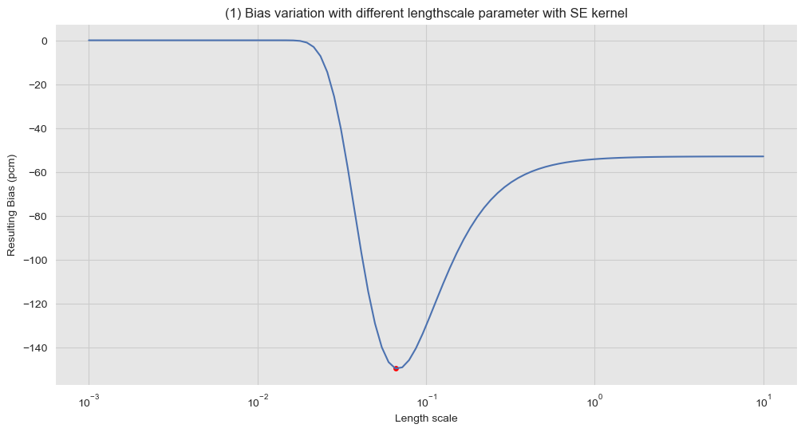

```
When the lengthscale is 0.0658,
                             the resulting bias reaches at its minimum value, -149.39 pcm
```

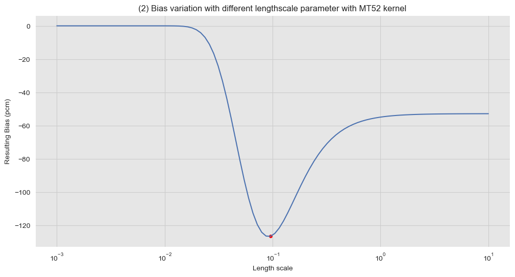

```
When the lengthscale is 0.0955,
                             the resulting bias reaches at its minimum value, -126.63 pcm
```

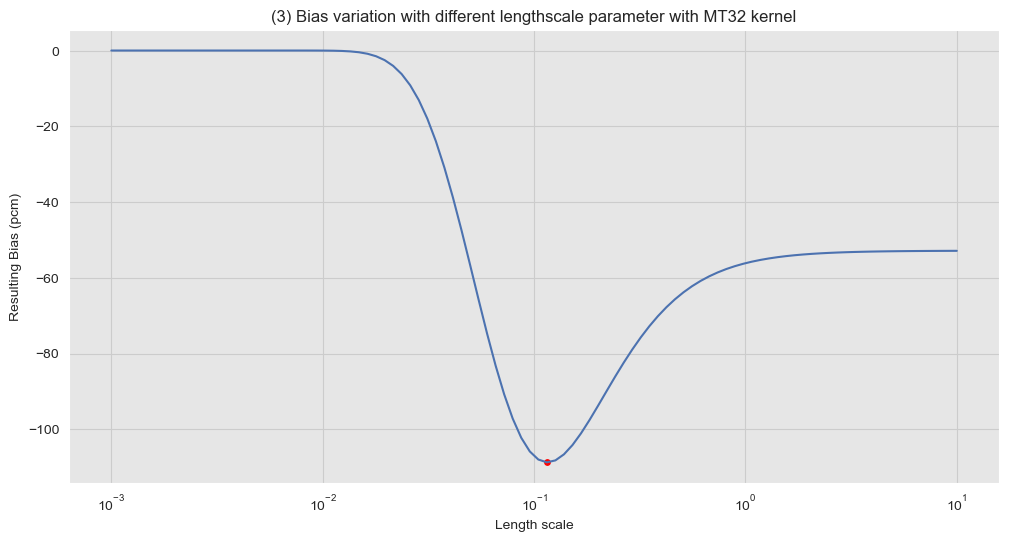

```
When the lengthscale is 0.1150,
                             the resulting bias reaches at its minimum value, -108.74 pcm
```

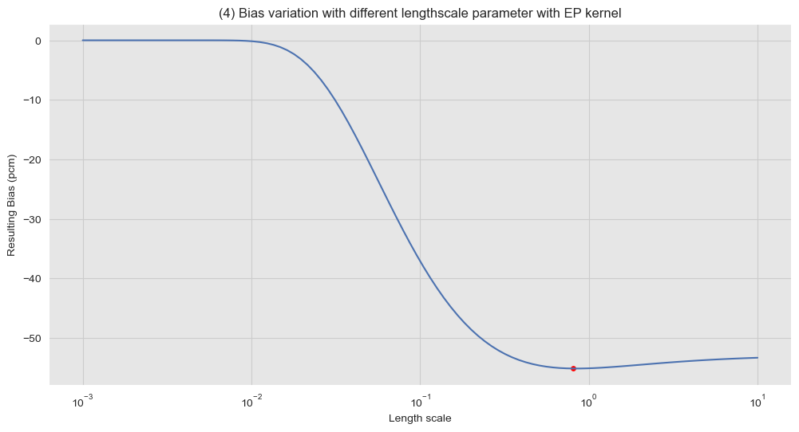

```
When the lengthscale is 0.8111,
                             the resulting bias reaches at its minimum value, -55.10 pcm
```

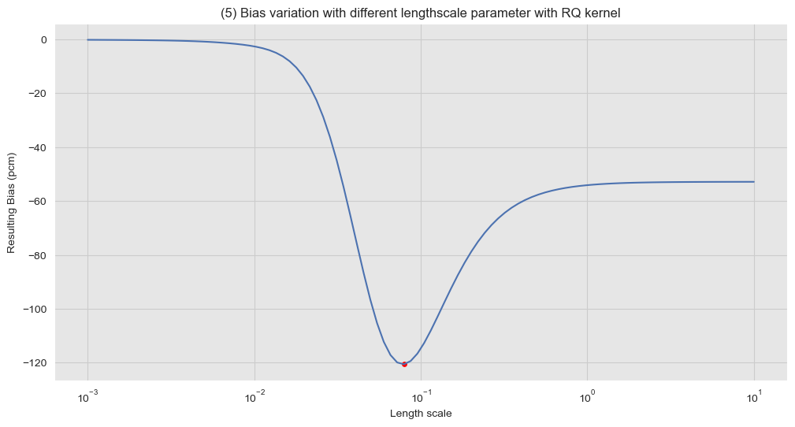

```
When the lengthscale is 0.0792,
                             the resulting bias reaches at its minimum value, -120.61 pcm
```

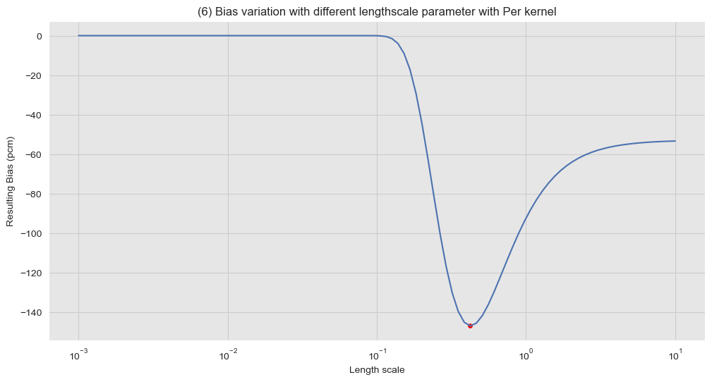

```
When the lengthscale is 0.4229,
                             the resulting bias reaches at its minimum value, -146.88 pcm
```

```python
kernels = ["SE", "MT52", "MT32", "EP", "RQ", "Per"]
                            lvlm = np.zeros((6,2))
                            for n in range(len(kernels)):
                                lenList = np.linspace(-3,1,100)
                                ll = pow(10, lenList)
                                COV = np.zeros((18,18))

                                RES = np.zeros((len(ll),2))
                                for k in range(len(ll)):
                                    for i in range(18):
                                        for j in range(18):
                                            COV[i,j] = GP_kernels(X[:,i],X[:,j],ker=kernels[n],sigma=1,length=ll[k])
                                    GP_Ckk = np.dot(np.dot(S,COV), S)
                                    GP_dk = -np.dot(np.dot(GP_Ckk[17,:],np.linalg.inv(GP_Ckk+Cmm)),d)
                                    GP_var = GP_Ckk[17,17] - np.dot(np.dot(GP_Ckk[17,:], np.linalg.inv(GP_Ckk+Cmm)), GP_Ckk[:,17])
                                    GP_unc = np.sqrt(GP_var)
                                    RES[k,0] = GP_dk*10**5
                                    RES[k,1] = GP_unc*10**5

                                mv = np.min(RES[:,0])
                                lv = ll[list(RES[:,0]).index(mv)]
                                lvlm[n,0] = lv; lvlm[n,1] = mv

                                plt.semilogx(ll,RES[:,0])
                                plt.scatter(lv,mv,s=15, c='r')
                                plt.xlabel('Length scale')
                                plt.ylabel('Resulting Bias (pcm)')
                                plt.title('({}) Bias variation with different lengthscale parameter with '.format(n+1)+kernels[n]+' kernel')
                                plt.show()
                                print("When the lengthscale is {0:.4f}, \n the resulting bias reaches at its minimum value, {1:.2f} pcm".format(lv,mv))
```

## Finding optimum values for the other parameter, $\alpha, p$

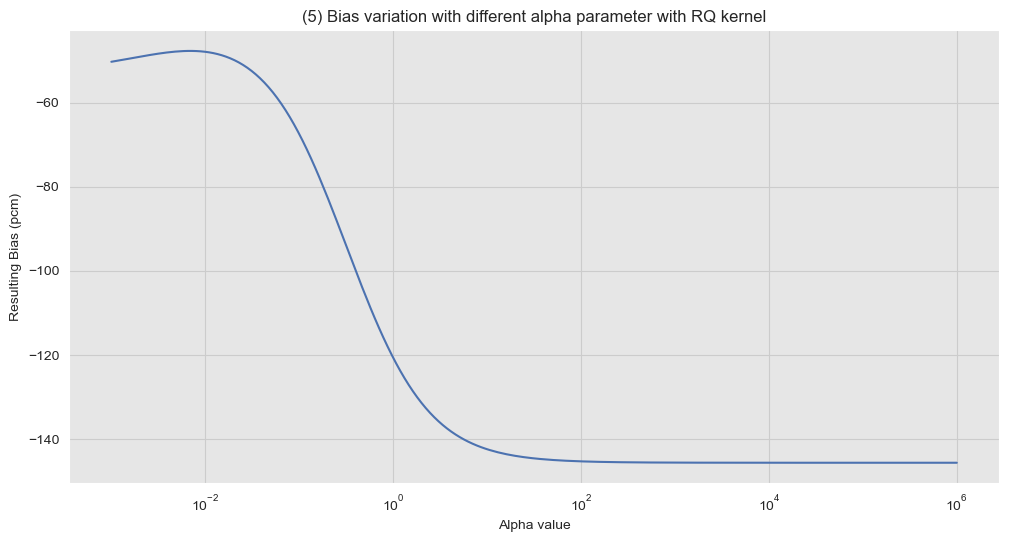

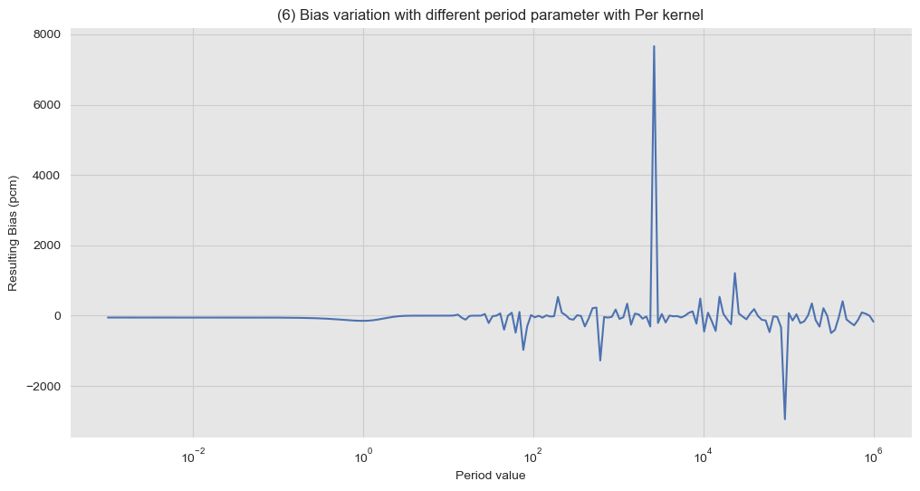

```python
kernels = ["RQ", "Per"]

                            for n in range(len(kernels)):
                                apList = np.linspace(-3,6,200)
                                ap = pow(10, apList)
                                COV = np.zeros((18,18))

                                RES = np.zeros((len(ap),2))
                                for k in range(len(ap)):
                                    for i in range(18):
                                        for j in range(18):
                                            COV[i,j] = GP_kernels(X[:,i],X[:,j],ker=kernels[n],sigma=1,length=lvlm[4+n,0], ap=ap[k])
                                    GP_Ckk = np.dot(np.dot(S,COV), S)
                                    GP_dk = -np.dot(np.dot(GP_Ckk[17,:],np.linalg.inv(GP_Ckk+Cmm)),d)
                                    GP_var = GP_Ckk[17,17] - np.dot(np.dot(GP_Ckk[17,:], np.linalg.inv(GP_Ckk+Cmm)), GP_Ckk[:,17])
                                    RES[k,0] = GP_dk*10**5
                                    RES[k,1] = GP_unc*10**5

                                mv = np.min(RES[:,0])
                                lv = ap[list(RES[:,0]).index(mv)]

                                plt.semilogx(ap,RES[:,0])
                                plt.ylabel('Resulting Bias (pcm)')
                                if n == 0:
                                    plt.xlabel('Alpha value')
                                    plt.title('({}) Bias variation with different alpha parameter with '.format(n+5)+kernels[n]+' kernel')
                                else:
                                    plt.xlabel('Period value')
                                    plt.title('({}) Bias variation with different period parameter with '.format(n+5)+kernels[n]+' kernel')
                                plt.show()
```

Let's take a look more closely with period parameter, from $10^{-2}$ to $10$

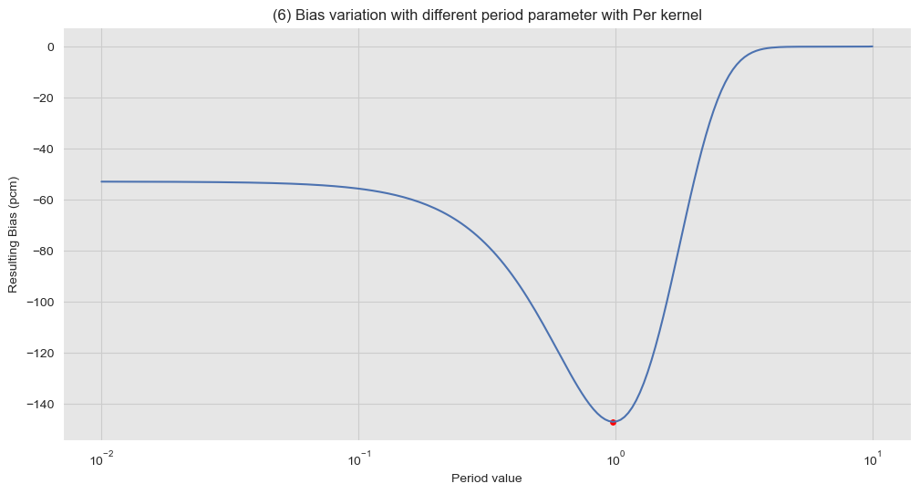

```
When the period value is 0.98,
                             the resulting bias reaches at its minimum value, -146.94 pcm
```

```python
apList = np.linspace(-2,1,200)
                            ap = pow(10, apList)
                            COV = np.zeros((18,18))

                            RES = np.zeros((len(ap),2))
                            for k in range(len(ap)):
                                for i in range(18):
                                    for j in range(18):
                                        COV[i,j] = GP_kernels(X[:,i],X[:,j],ker="Per",sigma=1,length=lvlm[5,0], ap=ap[k])
                                GP_Ckk = np.dot(np.dot(S,COV), S)
                                GP_dk = -np.dot(np.dot(GP_Ckk[17,:],np.linalg.inv(GP_Ckk+Cmm)),d)
                                GP_var = GP_Ckk[17,17] - np.dot(np.dot(GP_Ckk[17,:], np.linalg.inv(GP_Ckk+Cmm)), GP_Ckk[:,17])
                                RES[k,0] = GP_dk*10**5
                                RES[k,1] = GP_unc*10**5

                            mv = np.min(RES[:,0])
                            lv = ap[list(RES[:,0]).index(mv)]

                            plt.semilogx(ap,RES[:,0])
                            plt.scatter(lv,mv,s=15, c='r')
                            plt.ylabel('Resulting Bias (pcm)')
                            plt.xlabel('Period value')
                            plt.title('({}) Bias variation with different period parameter with '.format(6)+kernels[n]+' kernel')
                            plt.show()

                            print("When the period value is {0:.2f}, \n the resulting bias reaches at its minimum value, {1:.2f} pcm".format(lv,mv))
```

## Uncertainty analysis for the RBF kernel

[figure not shown]

```python
mu = np.min(RES[:,1])
                            lu = ll[list(RES[:,1]).index(mu)]

                            plt.semilogx(ll,RES[:,1])
                            plt.scatter(lu,mu,s=15, c='r')
                            plt.xlabel('Length scale')
                            plt.ylabel('Resulting Bias Uncertainty(pcm)')
                            plt.title('Bias uncertainty variation with different lengthscale parameter with SE kernel')
                            plt.show()
```